# Reproductive power function Covid-19 outbreak in the Netherlands

## The model used.

The early stage of an outbreak can be described by the infectiousness of the outbreak process, but in later stages of the outbreak, this is complicated by factors such as changing contact patterns and the impact of control measures. It is important to take these factors into account in order to get a good, if approximate, model for an outbreak process. For the covid-19 outbreak in the Netherlands, a non-homogeneous birth process is used for the (quasi) reproductive power function, similar to models in discrete survival analysis. A baseline reproductive power function gives a description of the outbreak.

The non-homogeneous birth model (negative binomial) for outbreak data depends on the reproductive power (probability) (“Modelling the reproductive power function”, van den Broek, J., 2020, Journal of Applied Statistics). This reproductive power is taken to be non-homogeneous in order to deal with developments later on in the outbreak. This non-homogeneous is important because, it allows the (quasi) reproductive power to adapt to other dynamics besides the infectious disease outbreak; dynamics such as changing contact patterns, the changing population of susceptible individuals, and control measures taken. Furthermore, in the case of a non-homogeneous reproductive power, there is no need to include a homogeneous mixing assumption. This is because such non-homogeneous mixing – for example if there are periods in which the infected individuals mix well with other individuals and periods in which this is less the case – can influence the number of infected individuals at certain time points and the non-homogeneous reproductive power can adapt to it. The model has the following features:

- The model is a non-homogeneous birth model so it can describe the early phase of the outbreak well and, due to its non-homogeneous nature, can deal with other aspects of the outbreak such as changing behavior or control measures taken besides.
- It does not need the size of an at-risk population; such a population is often hard to determine and can change during the outbreak.
- An infection is usually observed as having taken place in the past. This model deals with this in a way similar to current status data.
- Because the model is a Markov model, it deals with dependence in the data.
- Modelling the log-odds of the reproductive power probabilities (proportion new cases of all the infections at any one time) is the same as modelling the log of the reproductive power (proportion of new cases per existing case).

$R_p(t_{j})$ is the discrete quasi-reproductive power probability function hereafter referred to as the reproductive power probability function or shortly as the reproductive power probability. This is the probability that an infection will occur at $t_j$ given that it did not occur before that point in time. Or the probability that an previous infected individual will produce an infected at $t_j$.

The conditional probability of observing $z_{t_j}$ new infected individuals at time $t_j$ given $y_{t_{j-1}}$ infected individuals at the previous time point $t_{j-1}$ is:
$$\begin{align}
\label{nbprob}
P ( Z(t_j)=z_{t_j}|Y(t_{j-1})=y_{t_{j-1}} )={z_{t_j}+y_{t_{j-1}}-1 \choose y_{t_{j-1}}-1}\left[ 1-R_p(t_{j})\right]^{y_{t_{j-1}}} \left[R_p(t_{j}) \right]^{z_{t_j}}, z_{t_j}=0,1,\cdots \nonumber
\end{align}$$
The expected value is:
$$\begin{align}
\label{expect}
E[Z(t_j)]=\mu_{t_j}=y_{t_{j-1}}\frac{R_p(t_j)}{1-R_p(t_j)} ,
\end{align}$$

# The data

The data is taken from the website of the RIVM: https://www.rivm.nl/coronavirus-covid-19/grafieken The figure below shows the daily number of registrated covid-19 cases from 2020/2/27 until 2020/6/8

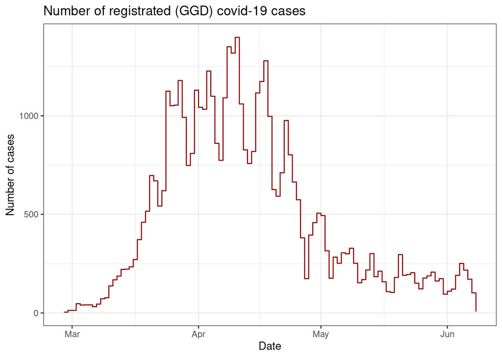

Note that the negative binomial distribution above, depends on the total number of previous infected by conditioning on it: given the total number of infected what is the probability of $Z(t_j)$ new cases. Because of this conditioning, the model is still valid if conditioning is done on the number of previous infected individuals in a limited amount of time. In this case fourteen days seems a reasonable time window. The reproductive power function then shows the probability of a newly infected individual on day $t_j$ per infected in the last 14 days.

The estimated reproductive power function is:

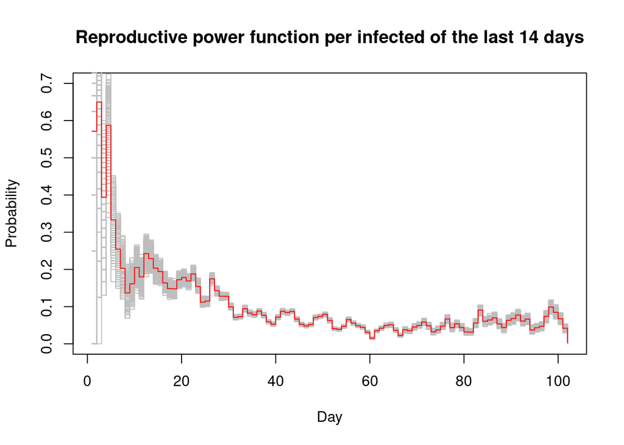

The beginning is quite messy since the conditioning is on less than 14 days. There is also a clear weekend effect as it is in the raw data. The gray lines are 1000 parametric bootstrap lines to show the uncertainty. There seems to roughly 4 periods: the first 30 days, between 30 an 60 days, between 60 and 80 days and the last approximately 3 weeks were the reproductive power seem to rise again. This means that per infected individual in the last 14 days the probability of producing an infected is larger as compared to the period before that.

# An extension: A Markov-switching model

A hidden Markov process consists of two parts. The first is an unobserved parameter process. So the reproductive power function might change over time because the underlying probability goes through a number of states. These states form a Markov model. So the state on time-point t depends only on the previous time point. The transition matrix determines the probability to go from one state to another.

The second part is the state-dependent part. Given the state it gives the probability of observing a number of new cases. For more details see ( Zucchini w., Macdonald I.L. and Langrock R.(2016), “Hidden Markov Models for TimeSeries. An Introduction Using R”. Second edition Boca Raton: CRC Press).

The state dependent distribution is taken to be the above negative binomial distribution which depends on the reproductive power probability. Since this distribution also depends on the history in a Markov way (it depends on the total number of infected in a previous period), in this model there are 2 of these dependencies, one in the state dependent distribution and one in the parameter process. Such a model is called a Markov switching model (see chapter 10. of Zucchine at.all.).

One is often interested in the most likely sequence of hidden states. This global decoding is achieved by maximizing the conditional probability of all the states given the data. This can be calculated using the Viterbi algorithm. (see chapter 5.4 about decoding in Zucchine at.all.)

Models with 2 until 9 states were fitted to the data. Due to the large dispersion in the time series of the covid-19 data it was difficult to find stable solutions. Nevertheless reasonable estimates were obtained. The model with 7 states fitted the data best according to Akaike’s Information Criterion (AIC). This large number of states might be explained by the large dispersion in the data especially the weekend effects might have an influence.

In the figure below the decoded path for the 7-state model is shown (blue line). Besides some going-up and going-down in this path one might roughly recognize 4 periods. So the decoded path for the 4-state model is also calculated and shown in the figure below (red line). The gray vertical line indicates the first 14 days.

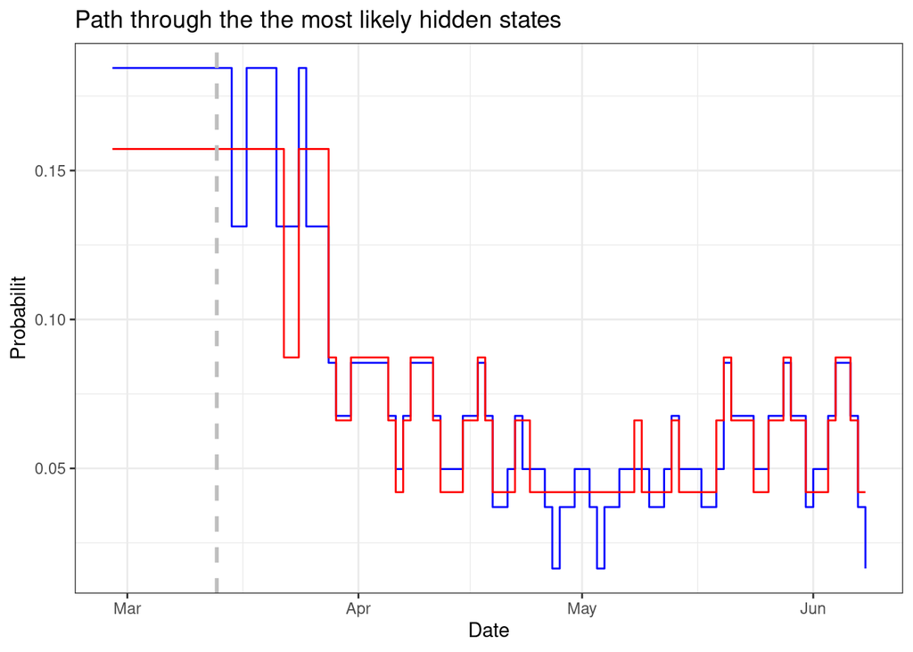

The periods are:

28-2 (12-3) until 31-3 with a most likely state probability of about 0.16; 1-4 until 22-4 with a most likely state probability of about 0.08; 23-4 until 19-5 with a most likely state probability of about 0.04 and 20-5 until 86 with a most likely state probability of about 0.07.

The figure below shows the reproductive power function with the uncertainty (parametric bootstrap lines) and the most likely state probability path from the 4 state model.

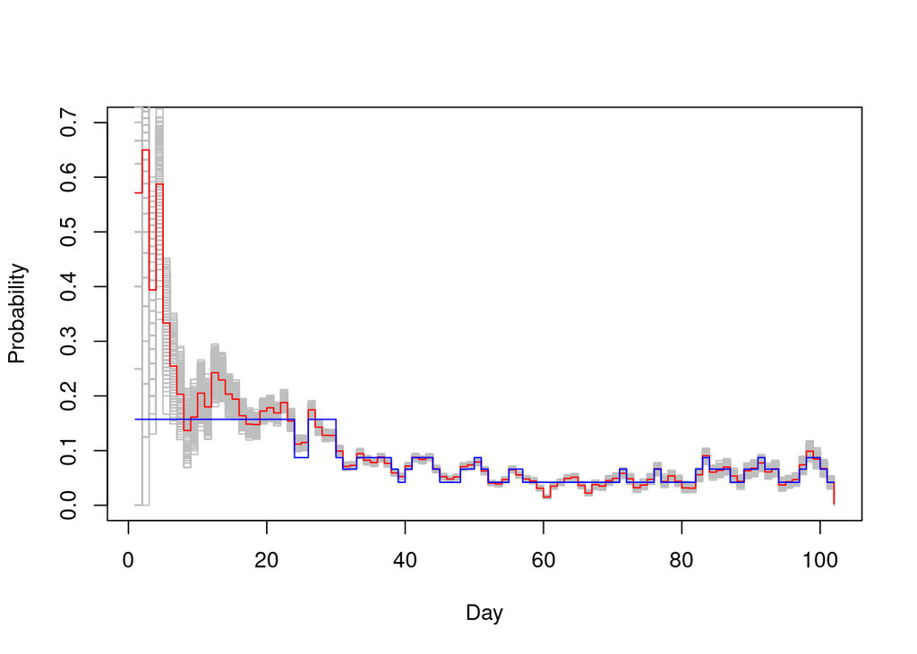